# Desindustrialización relativa en Argentina

Una comparación con economías de América del Sur, 2000-2025

Facundo Zunino

25/09/2026

# 1 Resumen ejecutivo

Este trabajo analiza las particularidades de la desindustrialización relativa de Argentina entre 2000 y 2025, en comparación con un grupo de países de América del Sur (Brasil, Chile, Colombia, Perú y Uruguay). El análisis se concentra en la evolución de la participación de la industria manufacturera en el Producto Interno Bruto (PIB) y complementa esta dimensión con indicadores de crecimiento económico y desempleo.

Para ello se utilizan datos del Banco Mundial **(BM)** y del Fondo Monetario Internacional **(FMI)**. La comparación permite evaluar si la pérdida de participación manufacturera observada en Argentina constituye una trayectoria particular o forma parte de un proceso general entre las economías consideradas.

# 2 Introducción

La desindustrialización constituye una de las dimensiones relevantes para analizar las transformaciones de la estructura productiva de un país. Sin embargo, cabe aclarar que una disminución de la participación de la industria manufacturera en el producto muestra una pérdida relativa del sector, pero no implica necesariamente una contracción de la producción industrial en términos absolutos.

En este marco, el presente trabajo estudia la trayectoria de Argentina durante el período 2000-2025 desde una perspectiva comparada con Brasil, Chile, Colombia, Perú y Uruguay.

La pregunta que guía el análisis es:

> **¿Qué particularidades presenta la trayectoria de desindustrialización relativa de Argentina entre 2000 y 2025 en comparación con los países de la región?**

Complementariamente, se analiza el desempeño de estas economías en términos de crecimiento y desempleo con el objetivo de caracterizar el contexto macroeconómico y laboral en el que se desarrolla la transformación productiva.

A su vez, la comparación regional permite evaluar en qué medida la trayectoria argentina presenta características propias o se inscribe dentro de tendencias compartidas en la región.

# 3 Desarrollo conceptual

Las transformaciones de la economía mundial iniciadas en la década de 1970 pueden analizarse a partir del concepto de Nueva División Internacional del Trabajo (NDIT). A diferencia de la división internacional clásica, caracterizada por una separación marcada entre países industriales y economías proveedoras de materias primas, la nueva configuración supone una creciente fragmentación e internacionalización de los procesos productivos.

Los avances tecnológicos, la automatización y las mejoras en transporte y comunicaciones permitieron distribuir distintas etapas de un mismo proceso de producción entre diferentes países.

En América Latina, estas transformaciones estuvieron asociadas con cambios importantes en las estructuras productivas y en las formas de inserción internacional. En el caso argentino, desde la década de 1970 se combinaron procesos de reestructuración industrial, mayor exposición a la competencia internacional y cambios en la composición de la producción.

En este marco, resulta importante distinguir entre desindustrialización absoluta y relativa. La primera supone una contracción de la producción industrial en términos absolutos, mientras que la segunda refiere a una pérdida de participación de la industria dentro de la estructura económica general. Una disminución de la participación manufacturera en el PIB no implica necesariamente que la producción industrial haya disminuido.

Las transformaciones productivas también se relacionan con cambios en el mercado de trabajo. La automatización y la reorganización de los procesos productivos modifican los requerimientos de fuerza de trabajo y pueden producir efectos heterogéneos sobre las calificaciones y las formas de empleo. En las economías menos desarolladas, estos procesos pueden coexistir además con informalidad, precariedad, subempleo y otras formas de inserción laboral.

Con este contexto de base, el trabajo analiza dos dimensiones complementarias. Por un lado, la participación de la industria manufacturera en el PIB permite aproximarse a la desindustrialización relativa, es decir, a la pérdida de peso de la manufactura dentro de la estructura económica general del país. Por otro, la evolución del valor agregado manufacturero a precios constantes permite observar si esa pérdida de participación estuvo acompañada por una contracción o una expansión de la actividad manufacturera en términos reales. La comparación entre Argentina y otras economías sudamericanas permite evaluar si estas trayectorias constituyen una particularidad argentina o forman parte de tendencias regionales más amplias.

# 4 Metodología

El análisis se organiza a partir de tres dimensiones. La principal corresponde a la evolución de la industria manufacturera y se estudia mediante dos indicadores complementarios a los cuales se hizo referencia anteriormente: su participación en el PIB y el valor agregado manufacturero a precios constantes.

Para facilitar la comparación entre países, el valor agregado manufacturero real se transforma en un índice con base 2000=100. De esta manera se compara la evolución de cada país respecto de su propio nivel inicial, evitando comparar directamente valores expresados en distintas monedas locales.

Como dimensiones complementarias se utilizan el crecimiento anual del PIB real y la tasa de desempleo, ambos provenientes del FMI. Para el crecimiento se calculan el promedio del período y su volatilidad mediante el desvío estándar de las tasas anuales.

# 5 Resultados y análisis

## 5.1 Evolución de la participación manufacturera

El primer paso consiste en analizar la evolución de la participación de la industria manufacturera en el PIB. Este indicador permite observar si la manufactura ganó o perdió peso relativo dentro de cada una de las economías consideradas durante el período analizado.

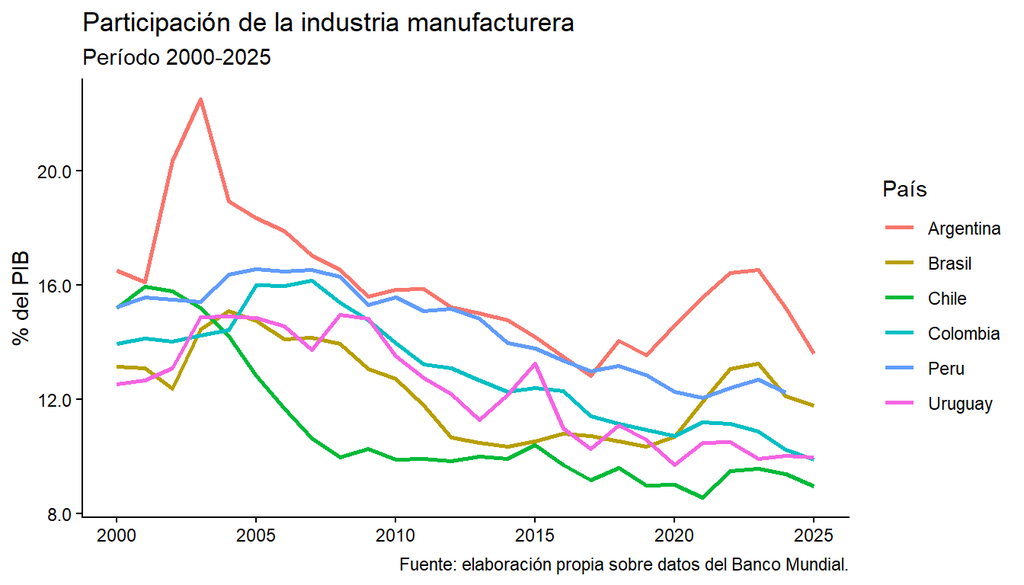

Lo que se puede observar es que la pérdida de peso relativo de la industria no constituye un fenómeno exclusivo de Argentina, sino una tendencia presente, aunque con diferencias, en las seis economías analizadas.

En Argentina, la participación de la manufactura presenta una trayectoria particular. Parte de 16,5% del PIB en 2000 y alcanza un máximo en 2003, luego de la fuerte contracción económica de 2002. A partir de allí comienza una tendencia predominantemente descendente y alcanza un mínimo en 2017. . Entre 2020 y 2023, probablemente como consecuencia de las restricciones por la pandemia del COVID, se observa una recuperación transitoria. Posteriormente, para 2025 cierra la serie representando el 13,6% del PIB.

La comparación regional permite observar que las trayectorias no son homogéneas. Mientras algunos países presentan descensos relativamente continuos, Argentina combina períodos de fuerte variación con una tendencia descendiente de largo plazo. Por lo que el caso argentino no parece ser algo exclusivo en lo referido a la desindustrialización relativa, ya que también se observa en las demás economías; en cambio si es marcada, y es un rasgo característico de la economía argentina, la variabilidad de su trayectoria.

## 5.2 Magnitud del cambio en la participación manufacturera

La evolución manufacturera se complementa con la comparación entre el primer y el último dato disponible para cada país. La variación se expresa en puntos porcentuales y permite comparar la magnitud de la pérdida o ganancia de participación a partir de los datos del producto.

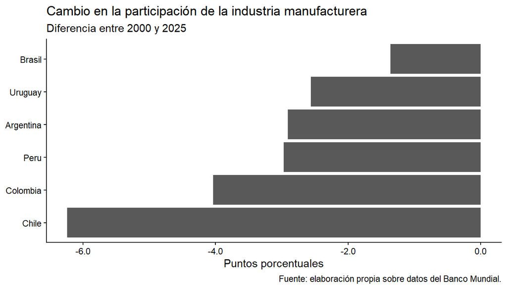

Este indicador confirma que los seis países registran una pérdida de participación de la manufactura en el PIB. Sin embargo, la magnitud del proceso presenta diferencias importantes.

Argentina muestra una disminución de 2,9 puntos porcentuales (pp). Esta caída es similar a la registrada por Perú (-3,0 pp) y algo superior a la de Uruguay (-2,6). Brasil presenta la reducción más moderada del grupo, con una caída de 1,4 pp.

En tanto que Chile y Colombia muestran pérdidas considerablemente mayores. La participación manufacturera chilena disminuye 6,2 pp, mientras que en Colombia la reducción alcanza 4,0 puntos.

Por lo tanto, durante el período considerado, Argentina no presenta la mayor pérdida relativa de participación manufacturera y si permite observa un proceso regional de reducción del peso de la manufactura, aunque con diferentes intensidades.

## 5.3 Evolución real de la industria manufacturera

La pérdida de participación de la manufactura no implica necesariamente una contracción de la actividad. Para distinguir ambos fenómenos, se analiza la evolución del valor agregado manufacturero a precios constantes mediante un índice con base 2000=100.

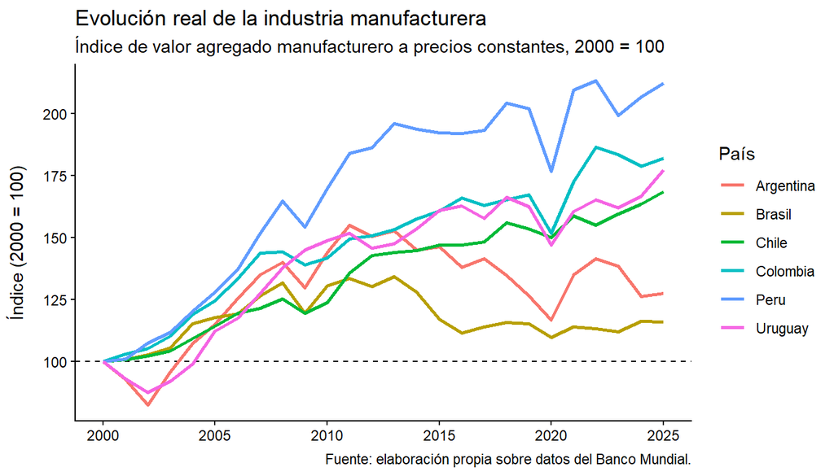

La comparación muestra que la pérdida de peso relativo de la manufactura respecto del PIB coexistió con un aumento de su valor agregado real en las seis economías analizadas. Entre 2000 y 2025, Argentina registra un crecimiento de aproximadamente 27,4%. Este incremento es superior únicamente al de Brasil (16,0%) y considerablemente menor que los observados en Chile (68,4%), Uruguay (77,1%), Colombia (82,0%) y Perú (112,2%).

Por lo que, la caída de 2,9 pp de la participación manufacturera, entre los extremos del período, no estuvo acompañada por una reducción del valor agregado manufacturero real.

## 5.4 Crecimiento económico y volatilidad

Una segunda dimensión del análisis corresponde al desempeño económico. Para cada país se compara la tasa de crecimiento promedio del PIB real con la volatilidad de ese crecimiento durante el período analizado.

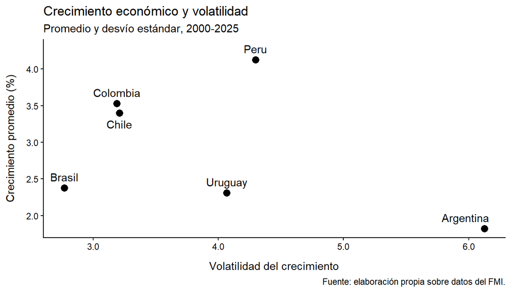

La comparación del crecimiento económico permite identificar la diferencia más marcada del caso argentino. Entre 2000 y 2025, Argentina registra un crecimiento promedio anual de 1,8%, el menor entre las seis economías analizadas. Al mismo tiempo, presenta una volatilidad de 6,1 pp medida mediante el desvío estándar de las tasas anuales de crecimiento, el valor más elevado del grupo.

El contraste regional es significativo. Perú presenta el mayor crecimiento promedio del período (4,1%), seguido por Colombia (3,5%) y Chile (3,4%). Brasil y Uruguay registran tasas promedio cercanas a 2,4% y 2,3%, respectivamente. En todos estos casos, la volatilidad del crecimiento es inferior a la argentina.

En consecuencia, la particularidad argentina aparece con mayor claridad cuando la transformación productiva se observa junto con el desempeño macroeconómico. La pérdida de participación manufacturera argentina no es excepcional por su magnitud, pero se desarrolla en una economía caracterizada por un crecimiento promedio comparativamente bajo y una elevada volatilidad.

## 5.5 Evolución del desempleo

La tercera, y última, dimensión considerada corresponde al mercado laboral. La evolución de la tasa de desempleo permite comparar las trayectorias laborales de las seis economías durante el mismo período.

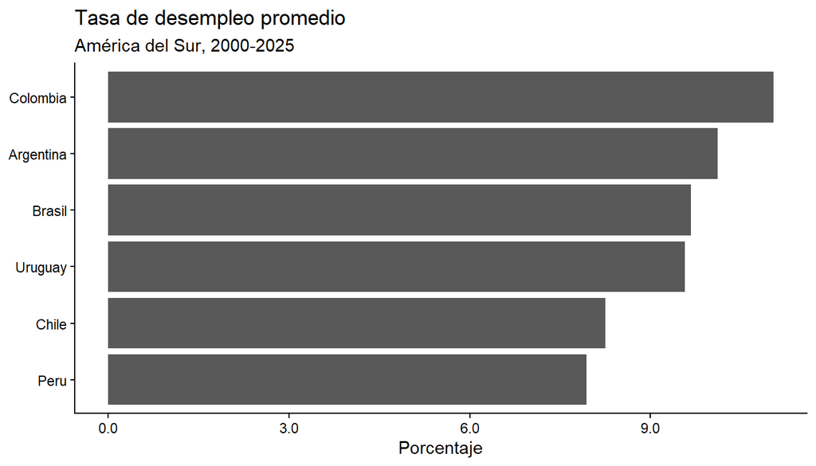

La evolución del desempleo muestra nuevamente diferencias importantes entre países y, en particular, una elevada variabilidad en el caso argentino. Argentina comienza el período con una tasa de desempleo de 17,1%, que aumenta hasta alcanzar 22,5% en 2002. Posteriormente se observa una disminución sostenida, hasta ubicarse en torno al 7% entre 2008 y 2015. El desempleo vuelve a aumentar entre 2016 y 2020, año en que alcanza 11,6%, para descender nuevamente durante la recuperación posterior.

Considerando el conjunto del período, Argentina registra una tasa de desempleo promedio de 10,1%. Este valor es inferior al promedio de Colombia (11,0%), pero superior a los registrados por Perú (7,9%), Chile (8,3%) y muy cerca de los valores de Uruguay (9,6%) y Brasil (9,7%).

La trayectoria argentina se caracteriza por variaciones importantes a lo largo del período. Sin embargo, los datos no muestran una correspondencia simple entre pérdida de participación manufacturera y aumento del desempleo. } Por ejemplo, durante varios años en los que disminuye el peso relativo de la manufactura también se reduce el desempleo.

En este caso, sería de mayor utilidad, hacer un estudio del desempleo por rama de actividad para conocer las dinamicas y trayectorias y poder construir una conclusión más especifica, en lo referido a la Desindustrialización.

## 5.6 Síntesis de resultados

La evidencia analizada muestra que la desindustrialización relativa no constituye una particularidad exclusiva de Argentina. Entre 2000 y 2025, los seis países registraron una reducción de la participación manufacturera en el PIB. En Argentina, esta pasó de 16,5% a 13,6%, una caída de 2,9 pp, menor que la observada en Chile y Colombia y similar a la de Perú. Sin embargo, esta pérdida relativa coexistió con un aumento de 27,4% del valor agregado manufacturero real respecto de 2000. Por lo tanto, la reducción del peso de la industria no implicó una contracción de su nivel real en el período.

La particularidad argentina aparece al considerar conjuntamente estas dimensiones. El crecimiento real de la manufactura fue relativamente moderado frente a la mayoría de los países analizados y coexistió con el menor crecimiento promedio del PIB y la mayor volatilidad macroeconómica del grupo. En materia laboral, Argentina también presentó importantes variaciones en el desempleo, aunque no se observa una correspondencia directa entre esta variable y la pérdida de participación manufacturera, ya que para sería necesario un análisis del empleo por rama de actividad.

En conjunto, los resultados permiten caracterizar la experiencia argentina como un proceso de desindustrialización relativa inserto en una tendencia regional más amplia, pero desarrollado en un contexto de desempeño macroeconómico particularmente inestable.

# 6 Referencias

Monteforte, E. y Bonals, S. (2014). *La Nueva División Internacional del Trabajo y sus consecuencias en la producción y en el mercado de trabajo argentino. 1970-2013*. I Congreso de Economía Política Internacional, Universidad Nacional de Moreno, Moreno.

Piva, A. (2024). *Las transformaciones en el capitalismo contemporáneo y los desafíos para la acción colectiva de los trabajadores. El caso argentino (1989-2019).* Trabajo y Sociedad, 42, 249-270.